# Proyecto final

Ingrid MM

30/11/2020

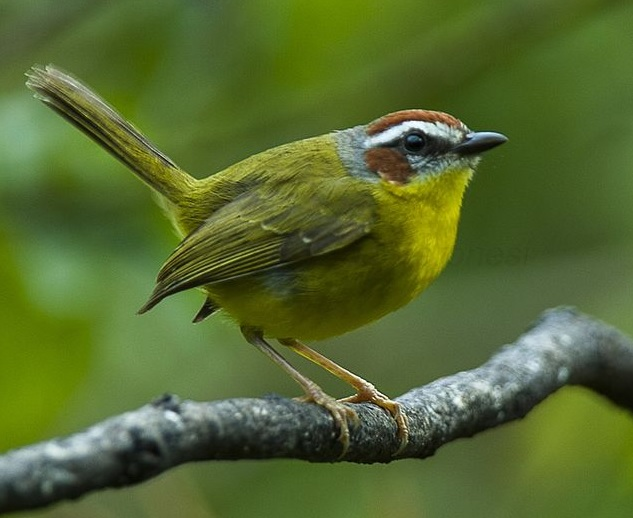

Reinita Cafetalera

### Antes de iniciar acá dejo esta lista de todos lo paquetes que vamos a necesitar para reproducir este análisis:

### Paquetes

install.packages(“tidyverse”)

install.packages(“dplyr”)

install.packages(“rlang_0.4.7”)

install.packages(“tidyr”)

install.packages(“readr”)

install.packages(“lattice”)

install.packages(“parallel”)

install.packages(“Rcpp”)

install.packages(“reshape2”)

install.packages(“ggdag”)

### Librerías:

library(sf)

library(rnaturalearth)

library(lubridate)

library(tidyverse)

library(readr)

library(plyr)

library(dplyr)

library(tidyr)

library(readr)

library(rlang)

library(unmarked)

library(MuMIn)

library(AICcmodavg)

library(ggdag)

### 1. ¿Cuál es la pregunta específica de investigación?

¿Hay una relación entre la complejidad estructural vegetal y la probabilidad de ocupación de especies de aves prioritarias para la conservación en las fincas cafetaleras de San Ramón?

Lo que espero es que para algunas especies comunes en los cafetales no haya diferencia, pero para las especies más dependientes de bosque y de preocupación mayor en las listas de especies en peligro o poblaciones vulnerables, sí haya un umbral de incremento en la probabilidad de ocupación respecto al aumento en la complejidad estructural vegetal.

Los datos para estimar la complejidad vegetal y las demás covariables no los tendremos listos sino hasta enero 2021 por lo que para este ejercicio utilizaré información de biomasa vegetal sobre el suelo como si fuera representativa de la complejidad vegetal, además de información del porcentaje de bosque.

### 2. ¿Cuáles son las variables relevantes y cuál es su relación, conocida y/o hipotética? Para esta pregunta debe presentar al menos un DAG, a menos que la pregunta sea 100% descriptiva y no causal.

La variable **independiente** es la Biomasa vegetal sobre el suelo= **B** La variable **dependiente** es la probabilidad de ocupación = **O**

B depende del **porcentaje de bosque (P)** y del tipo de cultivo, pero en este caso todas las fincas son de café. Además el porcentaje de bosque y la biomasa dependen el tipo de manejo de cada **finca (FI)** es decir si conservan el bosque ripario, si mantienen árboles de sombra en el café, si tienen remanentes de bosque en las fincas.

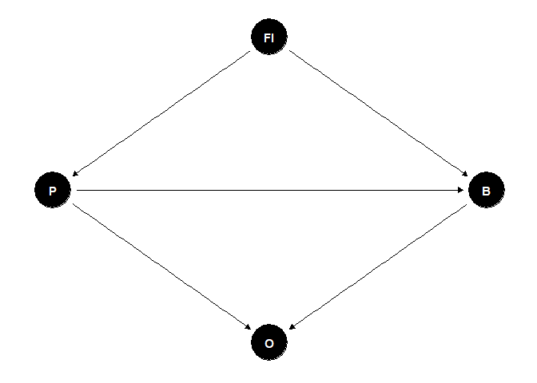

```r
DAG <- dagify(O~B, B~P, O~P, P~FI, B~FI, exposure = "B", outcome = "O")
ggdag(DAG, layout = "circle")+ theme_dag()
```

### 3. ¿De dónde vienen los datos? Si son datos empíricos debe incluir el código para su procesamiento desde datos crudos, hasta datos analizables.

Los datos vienen del trabajo de campo hecho desde finales de 2019 al 2020. Utilicé puntos de conteo de radio fijo de dos bandas (Anotamos las especies detectadas de 0 a 30m del punto y las detectadas de 30 a 100m del punto). Utilizamos la aplicación ebird para anotar todas las especies detectadas en cada uno de los 161 puntos. Al bajar de la aplicación toda la información obtengo unas tablas muy grandes por eso debo procesar los datos.

## Procesamiento de los datos:

El procesamiento es en general para las distintas preguntas que voy a responder en el proyecto, incluída la que expongo en este ejercicio.

Ahora leemos todos los datos que tenemos de los puntos de conteo hechos en Costa Rica

```r
CRdatos_all <- read.csv("C:/Users/in/Documents/MAESTRIA/Cursos/Estrategias/Trabajo_Final/MyEBirdData.csv",stringsAsFactors=FALSE)
head(CRdatos_all)
```

```
##   Submission.ID   Common.Name Scientific.Name Taxonomic.Order Count
## 1     S59642807 Great Tinamou   Tinamus major              39     1
## 2     S59891992 Great Tinamou   Tinamus major              39     1
## 3     S60138228 Great Tinamou   Tinamus major              39     1
## 4     S60220436 Great Tinamou   Tinamus major              39     1
## 5     S61000881 Great Tinamou   Tinamus major              39     1
## 6     S59033866 Great Tinamou   Tinamus major              39     1
##   State.Province County Location.ID                          Location Latitude
## 1           CR-A     NA   L11128927                        BPI-014-CR 10.11272
## 2           CR-A     NA   L11129538                        BPI-029-CR 10.10597
## 3           CR-A     NA   L11129808                        BPI-047-CR 10.12880
## 4           CR-A     NA   L11129826                        BPI-049-CR 10.12817
## 5           CR-A     NA   L11130100                        BPI-065-CR 10.12178
## 6           CR-A     NA    L9698019 Finca Asdrubal Gamboa - Nespresso 10.11396
##   Longitude       Date     Time                 Protocol Duration..Min.
```

[output cut: 27 more lines]

```r
dim(CRdatos_all)
```

```
## [1] 19839    23
```

```r
#vemos que hay un total de 19,839 registros
names(CRdatos_all)
```

```
##  [1] "Submission.ID"          "Common.Name"            "Scientific.Name"
##  [4] "Taxonomic.Order"        "Count"                  "State.Province"
##  [7] "County"                 "Location.ID"            "Location"
## [10] "Latitude"               "Longitude"              "Date"
## [13] "Time"                   "Protocol"               "Duration..Min."
## [16] "All.Obs.Reported"       "Distance.Traveled..km." "Area.Covered..ha."
## [19] "Number.of.Observers"    "Breeding.Code"          "Observation.Details"
## [22] "Checklist.Comments"     "ML.Catalog.Numbers"
```

Revisando notamos que hay algunos errores en los nombres científicos entonces hay que corregirlos:

```r
Data.CR.2020.BPI.rsp <- CRdatos_all[!grepl("sp,", CRdatos_all[["Scientific.Name"]]), ]
Data.CR.2020.BPI.rsp <- Data.CR.2020.BPI.rsp[!grepl("sp.", Data.CR.2020.BPI.rsp[["Scientific.Name"]]), ]
Data.CR.2020.BPI.rsp <- Data.CR.2020.BPI.rsp[!grepl("sp ", Data.CR.2020.BPI.rsp[["Scientific.Name"]]), ]


Data.CR.2020.BPI.rsp$Scientific.Name[which(Data.CR.2020.BPI.rsp$Scientific.Name == "Ramphocelus passerinii passerinii")] <- "Ramphocelus costaricensis"
Data.CR.2020.BPI.rsp$Scientific.Name[which(Data.CR.2020.BPI.rsp$Scientific.Name == "Ramphocelus passerinii costaricensis")] <- "Ramphocelus costaricensis"
Data.CR.2020.BPI.rsp$Scientific.Name[which(Data.CR.2020.BPI.rsp$Scientific.Name == "Empidonax alnorum/traillii")] <- "Empidonax traillii"

Lista.especies.all <- unique(Data.CR.2020.BPI.rsp$Scientific.Name)
length(Lista.especies.all)
```

```
## [1] 218
```

Verificamos que en Costa Rica hemos registrado un total de **218** especies distintas entre 2019 y 2020!

Posteriormente hacemos un subset de datos sólo con los puntos de conteo que establecimos mediante coordenadas.

```r
Data.CR.2020.BPI <- Data.CR.2020.BPI.rsp[grepl("BPI-", Data.CR.2020.BPI.rsp[["Location"]]), ]
names(Data.CR.2020.BPI)
```

```
##  [1] "Submission.ID"          "Common.Name"            "Scientific.Name"
##  [4] "Taxonomic.Order"        "Count"                  "State.Province"
##  [7] "County"                 "Location.ID"            "Location"
## [10] "Latitude"               "Longitude"              "Date"
## [13] "Time"                   "Protocol"               "Duration..Min."
## [16] "All.Obs.Reported"       "Distance.Traveled..km." "Area.Covered..ha."
## [19] "Number.of.Observers"    "Breeding.Code"          "Observation.Details"
## [22] "Checklist.Comments"     "ML.Catalog.Numbers"
```

```r
dim(Data.CR.2020.BPI)
```

```
## [1] 18435    23
```

```r
Datos_fincas <- Data.CR.2020.BPI[,c("Location","Latitude","Longitude")]

# Acá con distinct quito los dublicados
Datos_BPI_CR <- distinct(Datos_fincas)
dim(Datos_BPI_CR)
```

```
## [1] 161   3
```

```r
head(Datos_fincas)
```

```
##     Location Latitude Longitude
## 1 BPI-014-CR 10.11272 -84.55697
## 2 BPI-029-CR 10.10597 -84.55180
## 3 BPI-047-CR 10.12880 -84.51309
## 4 BPI-049-CR 10.12817 -84.51271
## 5 BPI-065-CR 10.12178 -84.55328
## 7 BPI-004-CR 10.07929 -84.50522
```

```r
##acá hacemos un archivo csv para tener ese sub set de datos por separado:

write.csv(Datos_BPI_CR,"Datos_BPI_CR.csv", row.names = FALSE)
Datos_BPI_CR$Location
```

```
##   [1] "BPI-014-CR" "BPI-029-CR" "BPI-047-CR" "BPI-049-CR" "BPI-065-CR"
##   [6] "BPI-004-CR" "BPI-017-CR" "BPI-034-CR" "BPI-039-CR" "BPI-040-CR"
##  [11] "BPI-041-CR" "BPI-042-CR" "BPI-044-CR" "BPI-045-CR" "BPI-064-CR"
##  [16] "BPI-068-CR" "BPI-071-CR" "BPI-080-CR" "BPI-105-CR" "BPI-115-CR"
##  [21] "BPI-117-CR" "BPI-134-CR" "BPI-135-CR" "BPI-139-CR" "BPI-001-CR"
##  [26] "BPI-002-CR" "BPI-003-CR" "BPI-005-CR" "BPI-006-CR" "BPI-007-CR"
##  [31] "BPI-008-CR" "BPI-010-CR" "BPI-011-CR" "BPI-012-CR" "BPI-016-CR"
##  [36] "BPI-018-CR" "BPI-019-CR" "BPI-020-CR" "BPI-022-CR" "BPI-024-CR"
##  [41] "BPI-025-CR" "BPI-026-CR" "BPI-027-CR" "BPI-028-CR" "BPI-030-CR"
##  [46] "BPI-035-CR" "BPI-037-CR" "BPI-038-CR" "BPI-043-CR" "BPI-046-CR"
##  [51] "BPI-048-CR" "BPI-050-CR" "BPI-051-CR" "BPI-052-CR" "BPI-053-CR"
##  [56] "BPI-054-CR" "BPI-055-CR" "BPI-056-CR" "BPI-057-CR" "BPI-058-CR"
##  [61] "BPI-059-CR" "BPI-060-CR" "BPI-061-CR" "BPI-062-CR" "BPI-066-CR"
##  [66] "BPI-067-CR" "BPI-069-CR" "BPI-072-CR" "BPI-075-CR" "BPI-077-CR"
##  [71] "BPI-081-CR" "BPI-082-CR" "BPI-086-CR" "BPI-088-CR" "BPI-090-CR"
```

[output cut: 18 more lines]

Luego separamos la fecha en varias columnas para año, mes y día. Esto porque luego nos es más fácil seleccionar datos de un sólo mes, por ejemplo (Pensando en que estos datos pueden ser utilizados por otras personas con otras preguntas dentro del mismo proyecto o fuera de este). La columna rec_1 es simplemente para colocar un 1 en cada observación.

```r
Data.CR.2020.BPI <- Data.CR.2020.BPI %>%
  dplyr::mutate(year = lubridate::year(Date),
                month = lubridate::month(Date),
                day = lubridate::day(Date),
                rec_1 = 1)
unique(Data.CR.2020.BPI$year)
```

```
## [1] 2019 2020
```

```r
dim(Data.CR.2020.BPI)
```

```
## [1] 18435    27
```

```r
head(Data.CR.2020.BPI)
```

```
##   Submission.ID    Common.Name   Scientific.Name Taxonomic.Order Count
## 1     S59642807  Great Tinamou     Tinamus major              39     1
## 2     S59891992  Great Tinamou     Tinamus major              39     1
## 3     S60138228  Great Tinamou     Tinamus major              39     1
## 4     S60220436  Great Tinamou     Tinamus major              39     1
## 5     S61000881  Great Tinamou     Tinamus major              39     1
## 6     S72117475 Little Tinamou Crypturellus soui              56     1
##   State.Province County Location.ID   Location Latitude Longitude       Date
## 1           CR-A     NA   L11128927 BPI-014-CR 10.11272 -84.55697 2019-09-09
## 2           CR-A     NA   L11129538 BPI-029-CR 10.10597 -84.55180 2019-09-17
## 3           CR-A     NA   L11129808 BPI-047-CR 10.12880 -84.51309 2019-09-26
## 4           CR-A     NA   L11129826 BPI-049-CR 10.12817 -84.51271 2019-09-26
## 5           CR-A     NA   L11130100 BPI-065-CR 10.12178 -84.55328 2019-10-18
## 6           CR-A     NA   L11128710 BPI-004-CR 10.07929 -84.50522 2020-07-30
##       Time                 Protocol Duration..Min. All.Obs.Reported
```

[output cut: 27 more lines]

```r
Lista.especies.total <- unique(Data.CR.2020.BPI$Scientific.Name)
length(Lista.especies.total)
```

```
## [1] 213
```

```r
CR_bird_info <- read.delim("C:/Users/in/Documents/MAESTRIA/Cursos/Estrategias/Trabajo_Final/Lista_Costa_Rica.txt",stringsAsFactors=FALSE)
PIF_bird_info <- read.csv("C:/Users/in/Documents/MAESTRIA/Cursos/Estrategias/Trabajo_Final/CA_PIF_DataBase.csv",stringsAsFactors=FALSE)
PIF_bird_info.red <- PIF_bird_info[,c(3,5,6)]
```

Posteriormente quiero sustraer sólo las columnas de interés para el análisis que son los nombres científicos, familias y orden.

```r
names(CR_bird_info)
```

```
##  [1] "X"            "Sci_name"     "Region"       "AOS_57"       "type"
##  [6] "C_name"       "PT.c"         "TB.r"         "PS.g"         "BD.g"
## [11] "CS"           "PS_BD"        "PT_TB"        "WatchList"    "Cont_concern"
## [16] "Major_hab"    "Red_list_16"  "NOT_IUCN"
```

```r
names(PIF_bird_info.red) <- c("Sci_name","Oder","Family")

#acá lo que hacemos es juntar la información de la lista "PIF" con la lista que tenemos de los conteos para tener todo en una sóla
CR_bird_info2 <- CR_bird_info %>% left_join(PIF_bird_info.red)
dim(CR_bird_info2)
```

```
## [1] 758  20
```

```r
names(CR_bird_info2)
```

```
##  [1] "X"            "Sci_name"     "Region"       "AOS_57"       "type"
##  [6] "C_name"       "PT.c"         "TB.r"         "PS.g"         "BD.g"
## [11] "CS"           "PS_BD"        "PT_TB"        "WatchList"    "Cont_concern"
## [16] "Major_hab"    "Red_list_16"  "NOT_IUCN"     "Oder"         "Family"
```

```r
#Acá sólo queremos tener las 213 especies que corresponden a nuestros conteos

Aves_CR_sub <- subset(CR_bird_info2, Sci_name %in% Lista.especies.total)
names(Aves_CR_sub)
```

```
##  [1] "X"            "Sci_name"     "Region"       "AOS_57"       "type"
##  [6] "C_name"       "PT.c"         "TB.r"         "PS.g"         "BD.g"
## [11] "CS"           "PS_BD"        "PT_TB"        "WatchList"    "Cont_concern"
## [16] "Major_hab"    "Red_list_16"  "NOT_IUCN"     "Oder"         "Family"
```

```r
dim(Aves_CR_sub)
```

```
## [1] 213  20
```

```r
Lista.especies.info <- unique(CR_bird_info$Sci_name)
```

Acontinuación, hay algunas especies en esas listas que usamos a las cuales no se les asignó un orden y/o familia, entonces las rellenamos acá.

```r
# missing_info <- setdiff(Lista.especies.total,Lista.especies.info)

#Acá relleno la información sobre los ordenes y familias que no estaban incluidas en las listas rojas.
which(is.na(Aves_CR_sub$Oder))
```

```
## [1]   2  26  62 104 122 141 176 184 212
```

```r
# 2  26  62 104 122 141 176 184 212
Aves_CR_sub[2,]
```

```
##      X           Sci_name     Region AOS_57     type                  C_name
## 18 105 Amazilia hoffmanni Costa Rica    381 landbird Blue-vented Hummingbird
##    PT.c TB.r PS.g BD.g CS PS_BD PT_TB WatchList       Cont_concern
## 18    4    2    3    4 13     7     6        NA Watch List - Yel-r
##           Major_hab Red_list_16 NOT_IUCN Oder Family
## 18 Secondary forest          LC       NA <NA>   <NA>
```

```r
Aves_CR_sub$Oder[2] <- "Caprimulgiformes"
Aves_CR_sub$Family[2] <- "Throchilidae"

Aves_CR_sub[26,]
```

```
##       X           Sci_name     Region AOS_57     type                    C_name
## 100 646 Philodice bryantae Costa Rica    321 landbird Magenta-throated Woodstar
##     PT.c TB.r PS.g BD.g CS PS_BD PT_TB WatchList     Cont_concern
## 100    4    3    5    5 17    10     7        NA Watch List - Red
##                    Major_hab Red_list_16 NOT_IUCN Oder Family
## 100 Montane evergreen forest          NT       NA <NA>   <NA>
```

```r
Aves_CR_sub$Oder[26] <- "Caprimulgiformes"
Aves_CR_sub$Family[26] <- "Throchilidae"

Aves_CR_sub[62,]
```

```
##        X             Sci_name     Region AOS_57     type              C_name
## 201 1275 Cyanoloxia cyanoides Costa Rica   2057 landbird Blue-black Grosbeak
##     PT.c TB.r PS.g BD.g CS PS_BD PT_TB WatchList Cont_concern
## 201    4    3    3    1 11     4     7         3           NC
##                             Major_hab Red_list_16 NOT_IUCN Oder Family
## 201 Tropical lowland evergreen forest          LC       NA <NA>   <NA>
```

```r
Aves_CR_sub$Oder[62] <- "Passeriformes"
Aves_CR_sub$Family[62] <- "Cardinalidae"

Aves_CR_sub[104,]
```

```
##         X          Sci_name     Region AOS_57     type                   C_name
## 403 24444 Melozone cabanisi Costa Rica  19999 landbird Cabanis's Ground-Sparrow
##     PT.c TB.r PS.g BD.g CS PS_BD PT_TB WatchList     Cont_concern
## 403    4    4    5    5 18    10     8         1 Watch List - Red
##                    Major_hab Red_list_16 NOT_IUCN Oder Family
## 403 Montane evergreen forest          LC       NA <NA>   <NA>
```

```r
Aves_CR_sub$Oder[104] <- "Passeriformes"
Aves_CR_sub$Family[104] <- "Passerellidae"

Aves_CR_sub[122,]
```

```
##        X              Sci_name     Region AOS_57     type            C_name
## 480 2884 Leiothlypis peregrina Costa Rica   1776 landbird Tennessee Warbler
##     PT.c TB.r PS.g BD.g CS PS_BD PT_TB WatchList Cont_concern        Major_hab
## 480    3   NA    1    1  5     2     3         3           NC Secondary forest
##     Red_list_16 NOT_IUCN Oder Family
## 480          LC       NA <NA>   <NA>
```

```r
Aves_CR_sub$Oder[122] <- "Passeriformes"
Aves_CR_sub$Family[122] <- "Parulidae"

Aves_CR_sub[141,]
```

```
##        X            Sci_name     Region AOS_57     type                 C_name
## 534 3201 Dryobates fumigatus Costa Rica    955 landbird Smoky-brown Woodpecker
##     PT.c TB.r PS.g BD.g CS PS_BD PT_TB WatchList Cont_concern
## 534    4    3    4    2 13     6     7         3           NC
##                    Major_hab Red_list_16 NOT_IUCN Oder Family
## 534 Montane evergreen forest          LC       NA <NA>   <NA>
```

```r
Aves_CR_sub$Oder[141] <- "Piciformes"
Aves_CR_sub$Family[141] <- "Dryobates"

Aves_CR_sub[176,]
```

```
##        X             Sci_name     Region AOS_57     type             C_name
## 639 3855 Sporophila morelleti Costa Rica   1920 landbird Variable Seedeater
##     PT.c TB.r PS.g BD.g CS PS_BD PT_TB WatchList Cont_concern
## 639    2    2    3    3 10     6     4         2           NC
##               Major_hab Red_list_16 NOT_IUCN Oder Family
## 639 Second-growth scrub          LC       NA <NA>   <NA>
```

```r
Aves_CR_sub$Oder[176] <- "Passeriformes"
Aves_CR_sub$Family[176] <- "Sporophila"

Aves_CR_sub[184,]
```

```
##        X         Sci_name     Region AOS_57     type                C_name PT.c
## 670 4045 Stilpnia larvata Costa Rica   1863 landbird Golden-hooded Tanager    4
##     TB.r PS.g BD.g CS PS_BD PT_TB WatchList Cont_concern
## 670    2    3    3 12     6     6         2           NC
##                             Major_hab Red_list_16 NOT_IUCN Oder Family
## 670 Tropical lowland evergreen forest          LC       NA <NA>   <NA>
```

```r
Aves_CR_sub$Oder[184] <- "Passeriformes"
Aves_CR_sub$Family[184] <- "Thraupidae"

Aves_CR_sub[212,]
```

```
##        X         Sci_name     Region AOS_57     type               C_name PT.c
## 757 4565 Zimmerius parvus Costa Rica   1171 landbird Mistletoe Tyrannulet    3
##     TB.r PS.g BD.g CS PS_BD PT_TB WatchList Cont_concern
## 757    2    3    3 11     6     5         2           NC
##                    Major_hab Red_list_16 NOT_IUCN Oder Family
## 757 Montane evergreen forest          LC       NA <NA>   <NA>
```

```r
Aves_CR_sub$Oder[212] <- "Passeriformes"
Aves_CR_sub$Family[212] <- "Tyrannidae"


names(Aves_CR_sub)
```

```
##  [1] "X"            "Sci_name"     "Region"       "AOS_57"       "type"
##  [6] "C_name"       "PT.c"         "TB.r"         "PS.g"         "BD.g"
## [11] "CS"           "PS_BD"        "PT_TB"        "WatchList"    "Cont_concern"
## [16] "Major_hab"    "Red_list_16"  "NOT_IUCN"     "Oder"         "Family"
```

Ahora quiero saber cuantas especies de las que tenemos registradas están en las listas de la IUCN.

```r
IUCN_counts <- Aves_CR_sub %>%
  group_by(Red_list_16) %>%
  tally

IUCN_VU_CR <- Aves_CR_sub$Sci_name[which(Aves_CR_sub$Red_list_16 == "VU")]
IUCN_NT_CR <- Aves_CR_sub$Sci_name[which(Aves_CR_sub$Red_list_16 == "NT")]
```

```r
WatchList_counts <- Aves_CR_sub %>%
  group_by(Cont_concern) %>%
  tally

Family_counts <- Aves_CR_sub %>%
  group_by(Family) %>%
  tally

CR_Family_List <- as.data.frame(Family_counts)

CR_Family_List
```

```
##            Family  n
## 1    Accipitridae  7
## 2     Alcedinidae  2
## 3        Anatidae  1
## 4        Apodidae  2
## 5        Ardeidae  4
## 6   Caprimulgidae  2
## 7    Cardinalidae  7
## 8     Cathartidae  2
## 9      Columbidae  8
## 10       Corvidae  2
## 11     Cotingidae  1
## 12       Cracidae  3
## 13      Cuculidae  4
## 14      Dryobates  1
```

[output cut: 32 more lines]

## 4. Análisis de los datos.

Para comenzar con el análisis de los datos, quiero primero ver cuantos registros tengo de cada especie

```r
Count_sp_obs <- ddply(Data.CR.2020.BPI,~Scientific.Name,summarise,species_count=length(unique(Submission.ID)))

Count_sp_obs <- Count_sp_obs[order(Count_sp_obs$species_count),]
```

```r
Count_sp_obs.red <- Count_sp_obs[Count_sp_obs$species_count >=100 & Count_sp_obs$species_count <= 500,]

Count_sp_obs
```

```
##                 Scientific.Name species_count
## 5            Amazona autumnalis             1
## 13          Atlapetes albinucha             1
## 21            Buteo jamaicensis             1
## 24          Butorides virescens             1
## 25             Cairina moschata             1
## 26            Calocitta formosa             1
## 27          Camptostoma imberbe             1
## 40       Chloroceryle americana             1
## 45              Ciccaba virgata             1
## 46             Coereba flaveola             1
## 48             Colibri cyanotus             1
## 62                Dacnis cayana             1
## 73          Empidonax virescens             1
## 79              Eurypyga helias             1
```

[output cut: 199 more lines]

Ahora podemos comenzar a hacer la matriz con la que vamos a trabajar. Primero necesito los datos correspondientes al año 2020

```r
Count_BPI_samp2020 <- ddply(Data.CR.2020.BPI[Data.CR.2020.BPI$year==2020,],~Location,summarise,Sampled_days=length(unique(Date)))

#Acá sólo quiero asegurarme de cuales fueron los meses muestreados este año
Months2020 <- sort(unique(Data.CR.2020.BPI$month[Data.CR.2020.BPI$year==2020]))
Months2020
```

```
## [1] 1 2 3 7 8 9
```

Acá ya puedo crear la matiz para todos los datos de Costa Rica en el año 2020

```r
J= 4 #el número de réplicas
n= nrow(Datos_BPI_CR)
Sites <- Datos_BPI_CR[,1]
CR_2020_Matrix <- matrix(0, nrow=n, ncol=J,dimnames=list(1:n, paste("survey", 1:J, sep="")))
```

En este momento agrego la información de la biomasa sobre el suelo (**OJO** hay dos archivos de biomasa para cada punto de conteo, uno con los valores de 0 a 30m y otro con los valores de 30 a 100m) y del tipo de uso del suelo (en el tipo de uso tenemos el porcentaje de bosque).

```r
LandUseCR_30m <- read.csv("C:/Users/in/Documents/MAESTRIA/Cursos/Estrategias/Trabajo_Final/LandUseCR_30m.csv")
head(LandUseCR_30m)
```

```
##   IDs Bosque.maduro Bosque.secundario No.forestal Nubes Pastos Sombra.de.nubes
## 1   1            17                13           0     0      0               0
## 2   2            27                 0           0     0      0               0
## 3   3             0                 0          29     0      0               0
## 4   4            11                 0          16     0      0               0
## 5   5            28                 0           0     0      0               0
## 6   6            21                 0           6     0      0               0
##   totales X..Bosque.maduro X..Bosque.secundario X..No.forestal X..Nubes
## 1      30        0.5666667            0.4333333      0.0000000        0
## 2      27        1.0000000            0.0000000      0.0000000        0
## 3      29        0.0000000            0.0000000      1.0000000        0
## 4      27        0.4074074            0.0000000      0.5925926        0
## 5      28        1.0000000            0.0000000      0.0000000        0
## 6      27        0.7777778            0.0000000      0.2222222        0
##   X..Pastos X..Sombra.de.nubes
## 1         0                  0
## 2         0                  0
## 3         0                  0
## 4         0                  0
## 5         0                  0
## 6         0                  0
```

```r
LandUseCR_100m <- read.csv("C:/Users/in/Documents/MAESTRIA/Cursos/Estrategias/Trabajo_Final/LandUseCR_100m.csv")
head(LandUseCR_100m)
```

```
##   IDs Bosque.maduro Bosque.secundario Pastos No.forestal Nubes Sombra.de.nubes
## 1   1           135               132     50           0     0               0
## 2   2           275                 0      0          37     0               0
## 3   3            52                 0      0         265     0               0
## 4   4           114                 0      0         199     0               0
## 5   5           267                24      0          23     0               0
## 6   6           210                26      0          77     0               0
##   totales X..Bosque.maduro X..Bosque.secundario X..No.forestal X..Nubes
## 1     317        0.4258675           0.41640379     0.00000000        0
## 2     312        0.8814103           0.00000000     0.11858974        0
## 3     317        0.1640379           0.00000000     0.83596215        0
## 4     313        0.3642173           0.00000000     0.63578275        0
## 5     314        0.8503185           0.07643312     0.07324841        0
## 6     313        0.6709265           0.08306709     0.24600639        0
##   X..Pastos X..Sombra.de.nubes
## 1 0.1577287                  0
## 2 0.0000000                  0
## 3 0.0000000                  0
## 4 0.0000000                  0
## 5 0.0000000                  0
## 6 0.0000000                  0
```

```r
LandUseCR_100m_red <- LandUseCR_100m[,c(1,9)]
CRbuff30_aboveGbio <- read.csv("C:/Users/in/Documents/MAESTRIA/Cursos/Estrategias/Trabajo_Final/CRbuff30_aboveGbio.csv")
head(CRbuff30_aboveGbio)
```

```
##   ID X10N_090W_t_aboveground_biomass_ha_2000   Location
## 1  1                                     732 BPI-014-CR
## 2  2                                     874 BPI-029-CR
## 3  3                                     494 BPI-047-CR
## 4  4                                     698 BPI-049-CR
## 5  5                                     591 BPI-065-CR
## 6  6                                     636 BPI-017-CR
##                     geometry
## 1 c(-84.5569653, 10.1127216)
## 2 c(-84.5518021, 10.1059736)
## 3 c(-84.5130944, 10.1287986)
## 4 c(-84.5127065, 10.1281729)
## 5 c(-84.5532837, 10.1217769)
## 6 c(-84.5571165, 10.1112232)
```

```r
names(CRbuff30_aboveGbio) <- c("ID","Biomass_30m","Location","Coordinates")
CRbuff100_aboveGbio <- read.csv("C:/Users/in/Documents/MAESTRIA/Cursos/Estrategias/Trabajo_Final/CRbuff100_aboveGbio.csv")
head(CRbuff100_aboveGbio)
```

```
##   ID X10N_090W_t_aboveground_biomass_ha_2000   Location
## 1  1                                    6532 BPI-014-CR
## 2  2                                    7921 BPI-029-CR
## 3  3                                    6730 BPI-047-CR
## 4  4                                    7240 BPI-049-CR
## 5  5                                    6297 BPI-065-CR
## 6  6                                    8836 BPI-017-CR
##                     geometry
## 1 c(-84.5569653, 10.1127216)
## 2 c(-84.5518021, 10.1059736)
## 3 c(-84.5130944, 10.1287986)
## 4 c(-84.5127065, 10.1281729)
## 5 c(-84.5532837, 10.1217769)
## 6 c(-84.5571165, 10.1112232)
```

```r
names(CRbuff100_aboveGbio) <- c("ID","Biomass_100m","Location","Coordinates")


#acontinuación  lo unimos todo en un sólo archivo
CR_Hab1 <- CRbuff30_aboveGbio %>% left_join(CRbuff100_aboveGbio)
names(LandUseCR_100m_red) <- c("ID","Per_Forest")
CR_Hab_BPI <- CR_Hab1 %>% left_join(LandUseCR_100m_red)
CR_Hab_BPI2 <- as.data.frame(CR_Hab_BPI[,c(3,2,5,6)])
```

Seguidamente estandarizo las variables que voy a utilizar para ver como está distribuidas (El histograma de porcentaje de bosque no es muy alentador sin embargo como estas no son las covariables que realmente voy a utlizar, vamos a dejarlo pasar, para fines del ejercicio).

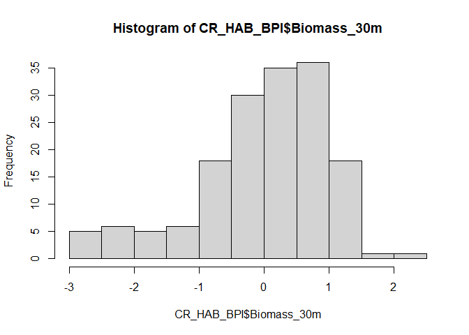

```r
CR_HAB_BPI <- as.data.frame(scale(CR_Hab_BPI2[,-c(1)]))
hist(CR_HAB_BPI$Biomass_30m)
```

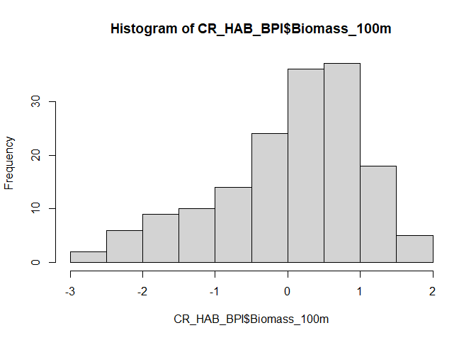

```r
hist(CR_HAB_BPI$Biomass_100m)
```

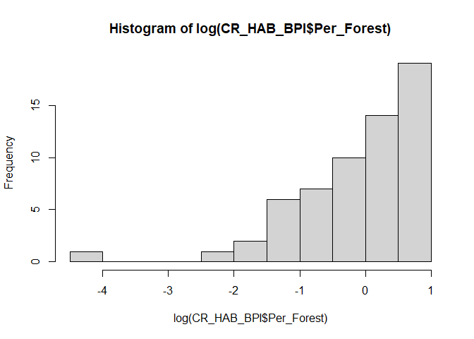

```r
hist(log(CR_HAB_BPI$Per_Forest))
```

Acá lo que hago es poner el nombre de los sitios como un caractér

```r
Sites_BPI_Obvs <- as.character(CR_Hab_BPI2[,1])
```

Ahora, voy a escoger sólo algunas especies para fines de este ejercicio. Por ejemplo: Especies que se encuentran en casi todos los puntos como *B.rufifrons*. Especies más “raras” y de interés turístico como *C. linearis*, especies migratorias que han visto sus poblaciones reducidas *I. galbula* y especies dependientes de bosque *L. souleyetii*

```r
Species_CR <- c("Lepidocolaptes souleyetii","Chiroxiphia linearis","Basileuterus rufifrons","Catharus aurantiirostris",
                 "Momotus lessonii","Icterus galbula","Catharus ustulatus","Sittasomus griseicapillus")
```

Y ahora vamos a explorar utilizando algunas de las distintas especies una por una. La reinita cafetalera (*B.rufifrons*) primero

```r
    sp.name <- Species_CR[3] # ponemos un 3 porque es la tercera especie en la lista que hicimos
    temp.det.mat <- CR_2020_Matrix  #esta es la matriz de presencia ausencia para cada una de las réplicas
    temp.data <- Data.CR.2020.BPI %>%
    filter(Scientific.Name == sp.name) %>%
    filter(year == 2020) %>%
    filter(month %in% Months2020[1:3]) #acá escojo sólo los primeros 3 meses de 2020
    temp.sites <- unique(temp.data$Location)
    site.match <- match(Sites_BPI_Obvs,temp.sites)
    site.idx <- !is.na(match(Sites_BPI_Obvs,temp.sites))
    for(ii in 1:length(Sites_BPI_Obvs)){
      if(site.idx[ii] == TRUE){
      temp.site <- temp.data %>%
        filter(Location == temp.sites[site.match[ii]])
        n.obs <- nrow(temp.site)
        if(n.obs > 4){
          n.obs <- 4;
        } #acá hice este ajuste porque hay sitios que tienen más de 4 réplicas en 2020 pero es porque son réplicas que correspondían al 2019 que se terminaron tarde y calleron en la primera temporada de muestreo de este año. Pero lo importante es que tengamos 4 réplicas de cada punto. Eventualmente separaremos esas réplicas de 2019.
        for(n in 1:n.obs){
          temp.det.mat[ii,n] <- 1;
        }
      }else if(site.idx[ii] == FALSE){
      temp.det.mat <- temp.det.mat
      }
    }
```

Le ponemos un **nombre código**, las tres primeras letras del género y tres primeras letras de la especie (Mantenemos este código en todas las especies) UMF significa UnMarked Frame Occupancy.

```r
BasRufUMF <- unmarkedFrameOccu(y = temp.det.mat,siteCovs = CR_HAB_BPI)
summary(BasRufUMF)
```

```
## unmarkedFrame Object
##
## 161 sites
## Maximum number of observations per site: 4
## Mean number of observations per site: 4
## Sites with at least one detection: 136
##
## Tabulation of y observations:
##   0   1
## 313 331
##
## Site-level covariates:
##   Biomass_30m       Biomass_100m       Per_Forest
##  Min.   :-2.6100   Min.   :-2.8180   Min.   :-0.7831
##  1st Qu.:-0.4849   1st Qu.:-0.5031   1st Qu.:-0.7831
##  Median : 0.1484   Median : 0.1530   Median :-0.6622
##  Mean   : 0.0000   Mean   : 0.0000   Mean   : 0.0000
##  3rd Qu.: 0.7561   3rd Qu.: 0.7653   3rd Qu.: 0.7142
##  Max.   : 2.2947   Max.   : 1.7268   Max.   : 2.1557
```

```r
str(BasRufUMF)
```

```
## Formal class 'unmarkedFrameOccu' [package "unmarked"] with 5 slots
##   ..@ y       : num [1:161, 1:4] 1 1 1 1 1 0 1 1 1 1 ...
##   .. ..- attr(*, "dimnames")=List of 2
##   .. .. ..$ : chr [1:161] "1" "2" "3" "4" ...
##   .. .. ..$ : chr [1:4] "survey1" "survey2" "survey3" "survey4"
##   ..@ obsCovs : NULL
##   ..@ siteCovs:'data.frame': 161 obs. of  3 variables:
##   .. ..$ Biomass_30m : num [1:161] 0.467 1.071 -0.544 0.323 -0.132 ...
##   .. ..$ Biomass_100m: num [1:161] -0.0145 0.6843 0.0851 0.3417 -0.1328 ...
##   .. ..$ Per_Forest  : num [1:161] 0.468 1.807 -0.301 0.287 1.716 ...
##   ..@ mapInfo : NULL
##   ..@ obsToY  : num [1:4, 1:4] 1 0 0 0 0 1 0 0 0 0 ...
```

```r
BasRufUMF[1:5,]
```

```
## Data frame representation of unmarkedFrame object.
##   y.1 y.2 y.3 y.4 Biomass_30m Biomass_100m Per_Forest
## 1   1   1   1   1   0.4671274  -0.01453463  0.4684136
## 2   1   0   0   0   1.0706576   0.68431817  1.8071451
## 3   1   1   1   1  -0.5444232   0.08508586 -0.3010413
## 4   1   1   1   1   0.3226202   0.34168408  0.2872382
## 5   1   0   0   0  -0.1321526  -0.13277106  1.7157738
```

Acontinuación el modelo nulo:

```r
(null <- occu(~1 ~1, BasRufUMF))
```

```
##
## Call:
## occu(formula = ~1 ~ 1, data = BasRufUMF)
##
## Occupancy:
##  Estimate    SE    z  P(>|z|)
##      1.89 0.262 7.21 5.59e-13
##
## Detection:
##  Estimate     SE    z  P(>|z|)
##      0.37 0.0942 3.93 8.43e-05
##
## AIC: 864.3388
```

```r
## La función Backtransform: transforma "de vuelta" psi(probabilidad de ocupación) y p(probabilidad de detección) a la escala original
# NOTA: esta función sólo funciona en el modelo nulo
backTransform(null, "state") #probabilidad de ocupación
```

```
## Backtransformed linear combination(s) of Occupancy estimate(s)
##
##  Estimate     SE LinComb (Intercept)
##     0.869 0.0299    1.89           1
##
## Transformation: logistic
```

```r
backTransform(null, "det") #probabilidad de detección
```

```
## Backtransformed linear combination(s) of Detection estimate(s)
##
##  Estimate     SE LinComb (Intercept)
##     0.592 0.0228    0.37           1
##
## Transformation: logistic
```

Acá el modelo global:

```r
# Modelo global ( con biomasa en ambas resoluciones)
full <- occu(~Biomass_100m +Biomass_30m ~Biomass_100m + Biomass_30m + Per_Forest, BasRufUMF)

occ_dredge <- dredge(full)
```

```
## Fixed terms are "p(Int)" and "psi(Int)"
```

```r
occ_dredge
```

```
## Global model call: occu(formula = ~Biomass_100m + Biomass_30m ~ Biomass_100m + Biomass_30m +
##     Per_Forest, data = BasRufUMF)
## ---
## Model selection table
##    p(Int) psi(Int) p(Bms_100) p(Bms_30m) psi(Bms_100) psi(Bms_30m) psi(Per_Frs)
## 10 0.3494    2.035     0.2676                               0.5428
## 11 0.3439    2.032               0.25670                    0.5236
## 26 0.3480    2.080     0.2614                               0.6284     -0.26390
## 2  0.3207    2.057     0.3403
## 3  0.3090    2.088               0.34500
## 12 0.3438    2.035     0.1850    0.10930                    0.5165
## 14 0.3454    2.057     0.2784              -0.2287000       0.7254
## 7  0.3338    2.036               0.28260    0.4212000
## 6  0.3465    1.996     0.2756               0.3999000
## 27 0.3444    2.066               0.24740                    0.6041     -0.24450
```

[output cut: 56 more lines]

```r
#Comparación de modelos para explorar los resultados para ocupación:
occ_dredge_table <- occ_dredge%>%
  mutate_all(~ round(., 3))

#Acá con la tabla de selección del modelo se puede observar cuales modelos tienen el mayor apoyo en el caso de esta especie.
Occ_res <- as.data.frame(occ_dredge_table)

Occ_res
```

```
##    p(Int) psi(Int) p(Biomass_100m) p(Biomass_30m) psi(Biomass_100m)
## 1   0.349    2.035           0.268             NA                NA
## 2   0.344    2.032              NA          0.257                NA
## 3   0.348    2.080           0.261             NA                NA
## 4   0.321    2.057           0.340             NA                NA
## 5   0.309    2.088              NA          0.345                NA
## 6   0.344    2.035           0.185          0.109                NA
## 7   0.345    2.057           0.278             NA            -0.229
## 8   0.334    2.036              NA          0.283             0.421
## 9   0.346    1.996           0.276             NA             0.400
## 10  0.344    2.066              NA          0.247                NA
## 11  0.309    2.096           0.194          0.190                NA
## 12  0.344    2.032              NA          0.257             0.000
## 13  0.344    2.070           0.188          0.098                NA
## 14  0.335    2.022           0.152          0.165             0.377
```

[output cut: 51 more lines]

Procedemos a la escogencia del mejor modelo utilizando el criterio de información de AKAIKE

```r
# Los modelos con menos de 2.5 Delta AICc)
occ_dredge_Delta <- get.models(occ_dredge, subset = delta <= 2.5)

# modelos promediados basados en el peso del modelo
occ_avg <- model.avg(occ_dredge_Delta, fit = TRUE)

#  coeficientes de los modelos promediados para lsa probabilidades de ocupación y detección. fr the models with the most support from the data
coef(occ_avg)
```

```
##          psi(Int)  psi(Biomass_30m)            p(Int)   p(Biomass_100m)
##         2.0501393         0.5759756         0.3379331         0.2617100
##    p(Biomass_30m)   psi(Per_Forest) psi(Biomass_100m)
##         0.2419696        -0.2564731         0.1885313
```

Creamos un nuevo data frame y hacemos el gráfico de probabilidad de ocupación respecto a biomasa de 0 a 30m

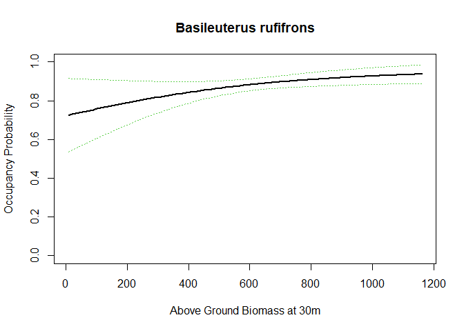

```r
newDatHab <- data.frame(Biomass_100m = mean(CR_HAB_BPI$Biomass_100m),
                        Biomass_30m = seq(min(CR_HAB_BPI$Biomass_30m),max(CR_HAB_BPI$Biomass_30m), length=100),
                        Per_Forest = mean(CR_HAB_BPI$Per_Forest))


occ_pred <- predict(occ_avg,
                    newdata = newDatHab,
                    type = "state")

Biomass_30m <- seq(min(CR_Hab_BPI2$Biomass_30m),max(CR_Hab_BPI2$Biomass_30m), length=100)

# par(mfrow=c(2,3))
plot(Biomass_30m, occ_pred$fit, xlab="Above Ground Biomass at 30m",
       ylab="Occupancy Probability", pch=16, ylim=0:1, type="l",
       lwd=2, main = Species_CR[3])
lines(Biomass_30m, occ_pred$fit-occ_pred$se.fit, lty=3,col=3)
lines(Biomass_30m, occ_pred$fit+occ_pred$se.fit, lty=3,col=3)
```

Creamos un nuevo data frame y hacemos el gráfico de probabilidad de ocupación respecto a biomasa a 100m

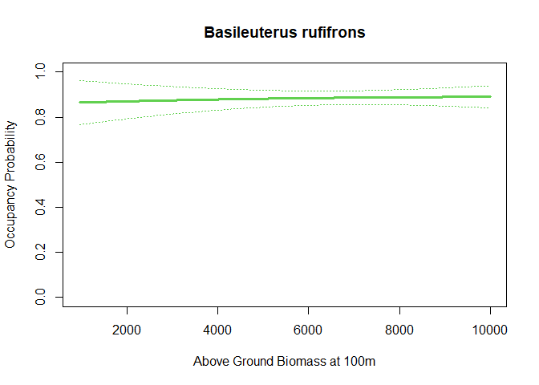

```r
newDatHab2 <- data.frame(Biomass_100m = seq(min(CR_HAB_BPI$Biomass_100m),max(CR_HAB_BPI$Biomass_100m), length=100),
                        Biomass_30m = mean(CR_HAB_BPI$Biomass_30m),
                         Per_Forest = mean(CR_HAB_BPI$Per_Forest))


 occ_pred2 <- predict(occ_avg,
                     newdata = newDatHab2,
                     type = "state")

 Biomass_100m <- seq(min(CR_Hab_BPI2$Biomass_100m),max(CR_Hab_BPI2$Biomass_100m), length=100)
 plot(Biomass_100m, occ_pred2$fit, xlab="Above Ground Biomass at 100m",
      ylab="Occupancy Probability", pch=16, ylim=0:1, type="l",
       #lwd=2, main = Species_CR[i])
      lwd=3, main = Species_CR[3],col=3)
 lines(Biomass_100m, occ_pred2$fit-occ_pred2$se.fit, lty=3,col=3)
lines(Biomass_100m, occ_pred2$fit+occ_pred2$se.fit, lty=3,col=3)
```

Ahora probamos con otra especie, el Toledo *C. linearis*

```r
 sp.name <- Species_CR[2] #acá ponemos un 2 porque es la segunda especie en la lista que hicimos
    temp.det.mat <- CR_2020_Matrix  #esta es la matriz de presencia ausencia para cada una de las réplicas
    temp.data <- Data.CR.2020.BPI %>%
    filter(Scientific.Name == sp.name) %>%
    filter(year == 2020) %>%
    filter(month %in% Months2020[1:3])
    temp.sites <- unique(temp.data$Location)
    site.match <- match(Sites_BPI_Obvs,temp.sites)
    site.idx <- !is.na(match(Sites_BPI_Obvs,temp.sites))
    for(ii in 1:length(Sites_BPI_Obvs)){
      if(site.idx[ii] == TRUE){
      temp.site <- temp.data %>%
        filter(Location == temp.sites[site.match[ii]])
        n.obs <- nrow(temp.site)
        if(n.obs > 4){
          n.obs <- 4;
        }
        for(n in 1:n.obs){
          temp.det.mat[ii,n] <- 1;
        }
      }else if(site.idx[ii] == FALSE){
      temp.det.mat <- temp.det.mat
      }
    }

    ChiLinUMF <- unmarkedFrameOccu(y = temp.det.mat,siteCovs = CR_HAB_BPI)
summary(ChiLinUMF)
```

```
## unmarkedFrame Object
##
## 161 sites
## Maximum number of observations per site: 4
## Mean number of observations per site: 4
## Sites with at least one detection: 33
##
## Tabulation of y observations:
##   0   1
## 583  61
##
## Site-level covariates:
##   Biomass_30m       Biomass_100m       Per_Forest
##  Min.   :-2.6100   Min.   :-2.8180   Min.   :-0.7831
##  1st Qu.:-0.4849   1st Qu.:-0.5031   1st Qu.:-0.7831
##  Median : 0.1484   Median : 0.1530   Median :-0.6622
##  Mean   : 0.0000   Mean   : 0.0000   Mean   : 0.0000
##  3rd Qu.: 0.7561   3rd Qu.: 0.7653   3rd Qu.: 0.7142
##  Max.   : 2.2947   Max.   : 1.7268   Max.   : 2.1557
```

```r
str(ChiLinUMF)
```

```
## Formal class 'unmarkedFrameOccu' [package "unmarked"] with 5 slots
##   ..@ y       : num [1:161, 1:4] 0 0 1 0 1 0 0 1 1 0 ...
##   .. ..- attr(*, "dimnames")=List of 2
##   .. .. ..$ : chr [1:161] "1" "2" "3" "4" ...
##   .. .. ..$ : chr [1:4] "survey1" "survey2" "survey3" "survey4"
##   ..@ obsCovs : NULL
##   ..@ siteCovs:'data.frame': 161 obs. of  3 variables:
##   .. ..$ Biomass_30m : num [1:161] 0.467 1.071 -0.544 0.323 -0.132 ...
##   .. ..$ Biomass_100m: num [1:161] -0.0145 0.6843 0.0851 0.3417 -0.1328 ...
##   .. ..$ Per_Forest  : num [1:161] 0.468 1.807 -0.301 0.287 1.716 ...
##   ..@ mapInfo : NULL
##   ..@ obsToY  : num [1:4, 1:4] 1 0 0 0 0 1 0 0 0 0 ...
```

```r
ChiLinUMF[1:5,]
```

```
## Data frame representation of unmarkedFrame object.
##   y.1 y.2 y.3 y.4 Biomass_30m Biomass_100m Per_Forest
## 1   0   0   0   0   0.4671274  -0.01453463  0.4684136
## 2   0   0   0   0   1.0706576   0.68431817  1.8071451
## 3   1   0   0   0  -0.5444232   0.08508586 -0.3010413
## 4   0   0   0   0   0.3226202   0.34168408  0.2872382
## 5   1   0   0   0  -0.1321526  -0.13277106  1.7157738
```

```r
#Acontinuación el modelo nulo:

(null <- occu(~1 ~1, ChiLinUMF))
```

```
##
## Call:
## occu(formula = ~1 ~ 1, data = ChiLinUMF)
##
## Occupancy:
##  Estimate    SE     z  P(>|z|)
##     -1.18 0.213 -5.55 2.82e-08
##
## Detection:
##  Estimate    SE     z P(>|z|)
##     -0.39 0.213 -1.83  0.0666
##
## AIC: 342.4815
```

```r
## Backtransform: transforma "de vuelta" psi y p a la escala original
# NOTA: esta función sólo funciona en el modelo nulo
backTransform(null, "state") #probabilidad de ocupación
```

```
## Backtransformed linear combination(s) of Occupancy estimate(s)
##
##  Estimate     SE LinComb (Intercept)
##     0.235 0.0382   -1.18           1
##
## Transformation: logistic
```

```r
backTransform(null, "det") #probabilidad de detección
```

```
## Backtransformed linear combination(s) of Detection estimate(s)
##
##  Estimate     SE LinComb (Intercept)
##     0.404 0.0512   -0.39           1
##
## Transformation: logistic
```

```r
# Modelo global (ie, con biomasa en ambas resoluciones)
full <- occu(~Biomass_100m +Biomass_30m ~Biomass_100m + Biomass_30m + Per_Forest, ChiLinUMF)

occ_dredge <- dredge(full)
```

```
## Fixed terms are "p(Int)" and "psi(Int)"
```

```r
occ_dredge
```

```
## Global model call: occu(formula = ~Biomass_100m + Biomass_30m ~ Biomass_100m + Biomass_30m +
##     Per_Forest, data = ChiLinUMF)
## ---
## Model selection table
##     p(Int) psi(Int) p(Bms_100) p(Bms_30m) psi(Bms_100) psi(Bms_30m)
## 16 -1.2300  -0.9880     1.7410   -0.99980      1.13700     -1.16400
## 12 -1.6750  -0.2615     2.3320   -1.32200                  -0.68520
## 4  -1.6370  -0.4247     2.2770   -1.54500
## 32 -1.2030  -1.0470     1.6930   -0.97750      1.12900     -1.17300
## 28 -1.6460  -0.3470     2.2870   -1.30000                  -0.66340
## 20 -1.5950  -0.5029     2.2190   -1.51400
## 8  -1.6670  -0.3716     2.3200   -1.55200     -0.07412
## 14 -0.7411  -1.2740     0.7101                 1.68000     -1.61100
## 24 -1.6240  -0.4553     2.2600   -1.52000     -0.06920
## 30 -0.7279  -1.3190     0.6782                 1.65000     -1.60600
```

[output cut: 56 more lines]

```r
#Comparación de modelos para explorar los resultados para ocupación:
occ_dredge_table <- occ_dredge%>%
  mutate_all(~ round(., 3))

#Acá con la tabla de selección del modelo se puede observar cuales modelos tienen el mayor apoyo en el caso de esta especie here you can see which models have the most support for this species
Occ_res <- as.data.frame(occ_dredge_table)

Occ_res
```

```
##    p(Int) psi(Int) p(Biomass_100m) p(Biomass_30m) psi(Biomass_100m)
## 1  -1.230   -0.988           1.741         -1.000             1.137
## 2  -1.675   -0.261           2.332         -1.322                NA
## 3  -1.637   -0.425           2.277         -1.545                NA
## 4  -1.203   -1.047           1.693         -0.977             1.129
## 5  -1.646   -0.347           2.287         -1.300                NA
## 6  -1.595   -0.503           2.219         -1.514                NA
## 7  -1.667   -0.372           2.320         -1.552            -0.074
## 8  -0.741   -1.274           0.710             NA             1.680
## 9  -1.624   -0.455           2.260         -1.520            -0.069
## 10 -0.728   -1.319           0.678             NA             1.650
## 11 -0.426   -1.513              NA             NA             2.083
## 12 -0.411   -1.483              NA             NA             2.106
## 13 -0.425   -1.512              NA          0.046             2.081
## 14 -0.410   -1.483              NA          0.051             2.104
```

[output cut: 51 more lines]

```r
#Procedemos a la escogencia del mejor modelo utilizando el criterio de información de AKAIKE

# Los modelos con menos de 2.5 Delta AICc)
occ_dredge_Delta <- get.models(occ_dredge, subset = delta <= 2.5)

# modelos promediados basados en el peso del modelo
occ_avg <- model.avg(occ_dredge_Delta, fit = TRUE)

#  coeficientes de los modelos promediados para lsa probabilidades de ocupación y detección.
coef(occ_avg)
```

```
##          psi(Int) psi(Biomass_100m)  psi(Biomass_30m)            p(Int)
##        -0.6112024         1.1337309        -0.9336784        -1.4841850
##   p(Biomass_100m)    p(Biomass_30m)   psi(Per_Forest)
##         2.0741568        -1.2546720         0.2858260
```

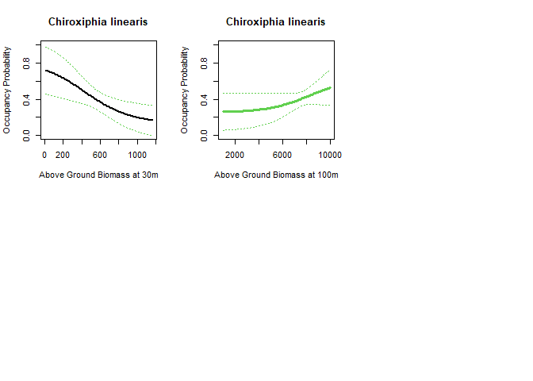

```r
#crear un data frame nuevo

newDatHab <- data.frame(Biomass_100m = mean(CR_HAB_BPI$Biomass_100m),
                        Biomass_30m = seq(min(CR_HAB_BPI$Biomass_30m),max(CR_HAB_BPI$Biomass_30m), length=100),
                        Per_Forest = mean(CR_HAB_BPI$Per_Forest))


occ_pred <- predict(occ_avg,
                    newdata = newDatHab,
                    type = "state")

Biomass_30m <- seq(min(CR_Hab_BPI2$Biomass_30m),max(CR_Hab_BPI2$Biomass_30m), length=100)

 par(mfrow=c(2,3))
plot(Biomass_30m, occ_pred$fit, xlab="Above Ground Biomass at 30m",
       ylab="Occupancy Probability", pch=16, ylim=0:1, type="l",
       lwd=2, main = Species_CR[2])
lines(Biomass_30m, occ_pred$fit-occ_pred$se.fit, lty=3,col=3)
lines(Biomass_30m, occ_pred$fit+occ_pred$se.fit, lty=3,col=3)



#crea un  data frame Prediciendo ocupación basandose en biomasa 100m

newDatHab2 <- data.frame(Biomass_100m = seq(min(CR_HAB_BPI$Biomass_100m),max(CR_HAB_BPI$Biomass_100m), length=100),
                        Biomass_30m = mean(CR_HAB_BPI$Biomass_30m),
                         Per_Forest = mean(CR_HAB_BPI$Per_Forest))


 occ_pred2 <- predict(occ_avg,
                     newdata = newDatHab2,
                     type = "state")

 Biomass_100m <- seq(min(CR_Hab_BPI2$Biomass_100m),max(CR_Hab_BPI2$Biomass_100m), length=100)

 plot(Biomass_100m, occ_pred2$fit, xlab="Above Ground Biomass at 100m",
      ylab="Occupancy Probability", pch=16, ylim=0:1, type="l",
       #lwd=2, main = Species_CR[i])
      lwd=3, main = Species_CR[2],col=3) #recordemos cambiar por un 2.
 lines(Biomass_100m, occ_pred2$fit-occ_pred2$se.fit, lty=3,col=3)
lines(Biomass_100m, occ_pred2$fit+occ_pred2$se.fit, lty=3,col=3)
```

Ahora queremos saber que sucede en el caso de *L. souleyetii*

```r
 sp.name <- Species_CR[1] #ponemos un 1 porque es la primera especie en la lista que hicimos
    temp.det.mat <- CR_2020_Matrix  #esta es la matriz de presencia ausencia para cada una de las réplicas
    temp.data <- Data.CR.2020.BPI %>%
    filter(Scientific.Name == sp.name) %>%
    filter(year == 2020) %>%
    filter(month %in% Months2020[1:3])
    temp.sites <- unique(temp.data$Location)
    site.match <- match(Sites_BPI_Obvs,temp.sites)
    site.idx <- !is.na(match(Sites_BPI_Obvs,temp.sites))
    for(ii in 1:length(Sites_BPI_Obvs)){
      if(site.idx[ii] == TRUE){
      temp.site <- temp.data %>%
        filter(Location == temp.sites[site.match[ii]])
        n.obs <- nrow(temp.site)
        if(n.obs > 4){
          n.obs <- 4;
        }
        for(n in 1:n.obs){
          temp.det.mat[ii,n] <- 1;
        }
      }else if(site.idx[ii] == FALSE){
      temp.det.mat <- temp.det.mat
      }
    }

    LepSouUMF <- unmarkedFrameOccu(y = temp.det.mat,siteCovs = CR_HAB_BPI)
summary(LepSouUMF)
```

```
## unmarkedFrame Object
##
## 161 sites
## Maximum number of observations per site: 4
## Mean number of observations per site: 4
## Sites with at least one detection: 29
##
## Tabulation of y observations:
##   0   1
## 606  38
##
## Site-level covariates:
##   Biomass_30m       Biomass_100m       Per_Forest
##  Min.   :-2.6100   Min.   :-2.8180   Min.   :-0.7831
##  1st Qu.:-0.4849   1st Qu.:-0.5031   1st Qu.:-0.7831
##  Median : 0.1484   Median : 0.1530   Median :-0.6622
##  Mean   : 0.0000   Mean   : 0.0000   Mean   : 0.0000
##  3rd Qu.: 0.7561   3rd Qu.: 0.7653   3rd Qu.: 0.7142
##  Max.   : 2.2947   Max.   : 1.7268   Max.   : 2.1557
```

```r
str(LepSouUMF)
```

```
## Formal class 'unmarkedFrameOccu' [package "unmarked"] with 5 slots
##   ..@ y       : num [1:161, 1:4] 0 0 1 1 0 0 0 1 0 0 ...
##   .. ..- attr(*, "dimnames")=List of 2
##   .. .. ..$ : chr [1:161] "1" "2" "3" "4" ...
##   .. .. ..$ : chr [1:4] "survey1" "survey2" "survey3" "survey4"
##   ..@ obsCovs : NULL
##   ..@ siteCovs:'data.frame': 161 obs. of  3 variables:
##   .. ..$ Biomass_30m : num [1:161] 0.467 1.071 -0.544 0.323 -0.132 ...
##   .. ..$ Biomass_100m: num [1:161] -0.0145 0.6843 0.0851 0.3417 -0.1328 ...
##   .. ..$ Per_Forest  : num [1:161] 0.468 1.807 -0.301 0.287 1.716 ...
##   ..@ mapInfo : NULL
##   ..@ obsToY  : num [1:4, 1:4] 1 0 0 0 0 1 0 0 0 0 ...
```

```r
LepSouUMF[1:5,]
```

```
## Data frame representation of unmarkedFrame object.
##   y.1 y.2 y.3 y.4 Biomass_30m Biomass_100m Per_Forest
## 1   0   0   0   0   0.4671274  -0.01453463  0.4684136
## 2   0   0   0   0   1.0706576   0.68431817  1.8071451
## 3   1   0   0   0  -0.5444232   0.08508586 -0.3010413
## 4   1   0   0   0   0.3226202   0.34168408  0.2872382
## 5   0   0   0   0  -0.1321526  -0.13277106  1.7157738
```

```r
#Acontinuación el modelo nulo:

(null <- occu(~1 ~1, LepSouUMF))
```

```
##
## Call:
## occu(formula = ~1 ~ 1, data = LepSouUMF)
##
## Occupancy:
##  Estimate    SE     z P(>|z|)
##    -0.702 0.396 -1.77  0.0765
##
## Detection:
##  Estimate    SE     z  P(>|z|)
##     -1.53 0.343 -4.46 8.15e-06
##
## AIC: 282.2322
```

```r
## Backtransform: transforma "de vuelta" psi y p a la escala original. Psi= probabilidad de ocupación y P= probabilidad de detección.

# NOTA: esta función sólo funciona en el modelo nulo
backTransform(null, "state") #probabilidad de ocupación
```

```
## Backtransformed linear combination(s) of Occupancy estimate(s)
##
##  Estimate     SE LinComb (Intercept)
##     0.331 0.0878  -0.702           1
##
## Transformation: logistic
```

```r
backTransform(null, "det") #probabilidad de detección
```

```
## Backtransformed linear combination(s) of Detection estimate(s)
##
##  Estimate     SE LinComb (Intercept)
##     0.178 0.0502   -1.53           1
##
## Transformation: logistic
```

```r
# Modelo global (ie, con biomasa en ambas resoluciones)
full <- occu(~Biomass_100m +Biomass_30m ~Biomass_100m + Biomass_30m + Per_Forest, LepSouUMF)

occ_dredge <- dredge(full)
```

```
## Fixed terms are "p(Int)" and "psi(Int)"
```

```r
occ_dredge
```

```
## Global model call: occu(formula = ~Biomass_100m + Biomass_30m ~ Biomass_100m + Biomass_30m +
##     Per_Forest, data = LepSouUMF)
## ---
## Model selection table
##    p(Int) psi(Int) p(Bms_100) p(Bms_30m) psi(Bms_100) psi(Bms_30m) psi(Per_Frs)
## 5  -1.553  -0.7239                             0.5472
## 11 -1.474  -0.6076               -0.6441                    1.1190
## 9  -1.555  -0.7183                                          0.5238
## 2  -1.710  -0.5523    0.44290
## 12 -1.526  -0.6045    0.52350    -0.9790                    1.0590
## 21 -1.554  -0.7280                             0.5947                   -0.2335
## 7  -1.473  -0.7464               -0.3069       0.7494
## 1  -1.529  -0.7023
## 27 -1.492  -0.5605               -0.6760                    1.2250      -0.2671
## 28 -1.564  -0.5236    0.59150    -1.0670                    1.2000      -0.3399
```

[output cut: 56 more lines]

```r
#Comparación de modelos para explorar los resultados para ocupación:
occ_dredge_table <- occ_dredge%>%
  mutate_all(~ round(., 3))

#Acá con la tabla de selección del modelo se puede observar cuales modelos tienen el mayor apoyo en el caso de esta especie here you can see which models have the most support for this species
Occ_res <- as.data.frame(occ_dredge_table)
Occ_res
```

```
##    p(Int) psi(Int) p(Biomass_100m) p(Biomass_30m) psi(Biomass_100m)
## 1  -1.553   -0.724              NA             NA             0.547
## 2  -1.474   -0.608              NA         -0.644                NA
## 3  -1.555   -0.718              NA             NA                NA
## 4  -1.710   -0.552           0.443             NA                NA
## 5  -1.526   -0.605           0.524         -0.979                NA
## 6  -1.554   -0.728              NA             NA             0.595
## 7  -1.473   -0.746              NA         -0.307             0.749
## 8  -1.529   -0.702              NA             NA                NA
## 9  -1.492   -0.560              NA         -0.676                NA
## 10 -1.564   -0.524           0.591         -1.067                NA
## 11 -1.555   -0.727              NA             NA             0.379
## 12 -1.472   -0.629              NA         -0.623             0.328
## 13 -1.731   -0.527           0.476             NA                NA
## 14 -1.528   -0.713          -0.161             NA             0.703
```

[output cut: 51 more lines]

```r
#Procedemos a la escogencia del mejor modelo utilizando el criterio de información de AKAIKE

# Los modelos con menos de 2.5 Delta AICc)
occ_dredge_Delta <- get.models(occ_dredge, subset = delta <= 2.5)

# modelos promediados basados en el peso del modelo
occ_avg <- model.avg(occ_dredge_Delta, fit = TRUE)

#  coeficientes de los modelos promediados para lsa probabilidades de ocupación y detección.
coef(occ_avg)
```

```
##          psi(Int) psi(Biomass_100m)            p(Int)  psi(Biomass_30m)
##        -0.6545574         0.5552659        -1.5547991         0.8226342
##    p(Biomass_30m)   p(Biomass_100m)   psi(Per_Forest)
##        -0.7194053         0.3852026        -0.2506797
```

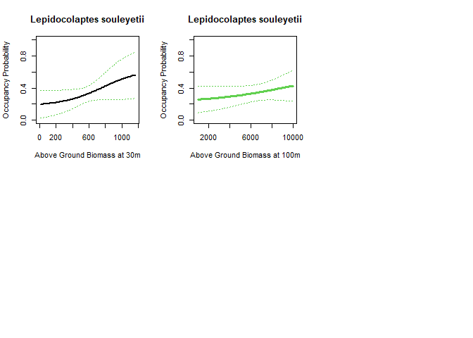

```r
#crear un data frame nuevo y usar la función predict() para predecir como sería la probabilidad de ocupación al aumentar la biomasa. Primero basandonos en biomasa a 30m.

newDatHab <- data.frame(Biomass_100m = mean(CR_HAB_BPI$Biomass_100m),
                        Biomass_30m = seq(min(CR_HAB_BPI$Biomass_30m),max(CR_HAB_BPI$Biomass_30m), length=100),
                        Per_Forest = mean(CR_HAB_BPI$Per_Forest))


occ_pred <- predict(occ_avg,
                    newdata = newDatHab,
                    type = "state")

Biomass_30m <- seq(min(CR_Hab_BPI2$Biomass_30m),max(CR_Hab_BPI2$Biomass_30m), length=100)

 par(mfrow=c(2,3))
plot(Biomass_30m, occ_pred$fit, xlab="Above Ground Biomass at 30m",
       ylab="Occupancy Probability", pch=16, ylim=0:1, type="l",
       lwd=2, main = Species_CR[1])
lines(Biomass_30m, occ_pred$fit-occ_pred$se.fit, lty=3,col=3)
lines(Biomass_30m, occ_pred$fit+occ_pred$se.fit, lty=3,col=3)


#creamos un nuevo data frame Prediciendo ocupación basandonos en la biomasa a escala de 100m

newDatHab2 <- data.frame(Biomass_100m = seq(min(CR_HAB_BPI$Biomass_100m),max(CR_HAB_BPI$Biomass_100m), length=100),
                        Biomass_30m = mean(CR_HAB_BPI$Biomass_30m),
                         Per_Forest = mean(CR_HAB_BPI$Per_Forest))


 occ_pred2 <- predict(occ_avg,
                     newdata = newDatHab2,
                     type = "state")

 Biomass_100m <- seq(min(CR_Hab_BPI2$Biomass_100m),max(CR_Hab_BPI2$Biomass_100m), length=100)

 plot(Biomass_100m, occ_pred2$fit, xlab="Above Ground Biomass at 100m",
      ylab="Occupancy Probability", pch=16, ylim=0:1, type="l",
      lwd=3, main = Species_CR[1],col=3)
 lines(Biomass_100m, occ_pred2$fit-occ_pred2$se.fit, lty=3,col=3)
lines(Biomass_100m, occ_pred2$fit+occ_pred2$se.fit, lty=3,col=3)
```

### Acá pueden acceder al

[Repositorio en github](https://github.com/MolinaIngrid/Trabajo_Final) En el archivo **README** hay más detalles sobre las decisiones que tomé para este ejercicio